# DOMAIN: Telecom

```python
from sklearn.model_selection import RandomizedSearchCV
from sklearn.metrics import roc_auc_score
from sklearn.model_selection import StratifiedKFold
from xgboost import XGBClassifier
```

```python
from sklearn.model_selection import GridSearchCV

clf = XGBClassifier()
parameters = {
     "max_depth"        : [ 3, 6,10],
     "learning_rate"    : [0.1,0.3],
     "min_child_weight" : [ 1, 3, 5, 7 ],
     "n_estimators"     : [100, 500],
     "gamma"            : [ 0.0, 0.1 ],
     "colsample_bytree" : [ 0.3, 0.7 ]
     }

grid = GridSearchCV(clf, parameters ,verbose = 3)

grid.fit(X_train, y_train)
```

[output not shown]

[output cut: 906 more lines]

[output not shown]

```
GridSearchCV(estimator=XGBClassifier(base_score=None, booster=None,
                                     callbacks=None, colsample_bylevel=None,
                                     colsample_bynode=None,
                                     colsample_bytree=None,
                                     early_stopping_rounds=None,
                                     enable_categorical=False, eval_metric=None,
                                     gamma=None, gpu_id=None, grow_policy=None,
                                     importance_type=None,
                                     interaction_constraints=None,
                                     learning_rate=None, max_bin=None,
                                     max_cat_to_...
                                     max_leaves=None, min_child_weight=None,
                                     missing=nan, monotone_constraints=None,
                                     n_estimators=100, n_jobs=None,
                                     num_parallel_tree=None, predictor=None,
                                     random_state=None, reg_alpha=None,
                                     reg_lambda=None, ...),
             param_grid={'colsample_bytree': [0.3, 0.7], 'gamma': [0.0, 0.1],
                         'learning_rate': [0.1, 0.3], 'max_depth': [3, 6, 10],
                         'min_child_weight': [1, 3, 5, 7],
                         'n_estimators': [100, 500]},
             verbose=3)
```

```python
print((grid.score(X_train, y_train)))
print((grid.score(X_test[X_train.columns], y_test)))
```

```
0.8150514731984381
0.8055358410220014
```

### Part 2 - Build a machine learning pipeline that will run autonomously with the csv file and return bestperforming model

1. Create separate function fo every step individually. For Example: Separate function to remove null values, separate function for normalization etc. On top of it, if you could build some rule based logic, you’ll gain better experience.
2. Once you are done with building smaller functions, you can group similar functions into another function to proceed with. For Example: create a function ‘preprocessing_’ and call all the preprocessing related functions within that function.
3. Once done with this, Stack all the functions sequentially within ‘main’ function to conclude.
4. Here, knowledge and skills required are of Supervised Learning and Python module only.
5. By building function modules in workflows, you will start gaining industry best practices as you go further in the AIML program else only marks are gained with traditional approach of programming.
6. If this project is solved by traditional approach, evaluation will be done out of 20 Marks. And if industry approach is followed successfully, bonus of 10 marks will awarded and evaluation will be done out of 30 Marks.

```python
from sklearn.pipeline import Pipeline
from sklearn.linear_model import LogisticRegression
from sklearn.tree import DecisionTreeClassifier
from sklearn.neighbors import KNeighborsClassifier
from sklearn.naive_bayes import GaussianNB
from sklearn.svm import SVC
from sklearn.ensemble import AdaBoostClassifier, GradientBoostingClassifier, RandomForestClassifier, VotingClassifier
from sklearn.model_selection import KFold, StratifiedKFold, cross_val_score, GridSearchCV
from sklearn.preprocessing import LabelEncoder, OneHotEncoder, StandardScaler, MinMaxScaler
from imblearn.over_sampling import SMOTE
import pickle
from sklearn import preprocessing
```

### DEFINING DATA and Returning

```python
def load_dataset(filename):
    df = pd.read_csv(filename)
    print("DATA loaded",df.shape)
    return df
```

### DATA CLEANING

```python
class Datacleaning:
    def __init__(self,df,unwantedcolumn):
        self.dropduplicates()
        self.dropunwantedcolumns(unwantedcolumn)
        self.check_missingvalues(df)
        self.datatype_conversion()


    def dropduplicates(self):
        print("Dropping duplicates - <If applies> ")
        df.drop_duplicates(keep='first', inplace=True)


    #Dropin unwanted coulmns
    def dropunwantedcolumns(self,column):
        if (column != ''):
            df.drop(column, axis=1,inplace=True)
            print("Dropped unwanted column -",column)


    #Checks for missing value and unexpected values and impute with relevant data
    def check_missingvalues(self,dataframe):
        print("\n-------Checking Missing and unexpected values------\n")
        missingvalue = False
        unexpected_values = ["n/a", "na", "--", " ","?","-","@","#","n-a"]

        for feature in dataframe.columns:
             #check for NaN values
            if(dataframe[feature].isnull().sum()!=0 or dataframe[feature].isna().sum()!=0 ):
                print("Data missing in column", feature)
                #call impute func to replace null vales
                self.impute(feature)
                missingvalue= True

            #check for unexpected values like special characters.
            if (not dataframe[dataframe[feature].isin(unexpected_values)].empty):
                print("Unexpected value found in",feature,"column in the indices ", dataframe[dataframe[feature].isin(unexpected_values)].index)
                #changing unexpected values to NaN
                df.replace(unexpected_values,np.nan, inplace=True)
                #call impute func to replace null values
                self.impute(feature)

        if(not missingvalue):
            print("No missing value in dataframe")



    #imputing missing value with mode for categorical and mean for numerical
    def impute(self,feature):
        print("\n------Imputing Missing and unexpected values------\n ")
        #for categorical , replacing with most frequent occurrence
        if (df[feature].dtypes =="object"):
            df[feature].fillna(df[feature].mode()[0], inplace=True)
            print("Imputed column",df[feature].dtypes ,feature,"with mode",df[feature].mode()[0])

        #For numerical replace with mean
        else:
            df[feature].fillna(df[feature].mean(), inplace=True)
            print("Imputed column" ,feature,"with Mean")
        print("\n ")


    #trying to convert feature to float if it is possible ; for strings it will raise exception and we we will not change that feature types
    def datatype_conversion(self):
        print(" \n------Data Type conversion ------\n")
        for feature in df.columns:
            try:
                df[feature]=pd.to_numeric(df[feature])
                df[feature]=df[feature].astype('float64')
                print("Converted to float64 -", feature)
            except:
                continue


    #Outlier detection for features
    def outlierdetection(self):
        print(" \n------ Outlier Detection ------\n")
        Q1 = df.quantile(0.25)
        Q3 = df.quantile(0.75)
        IQR = Q3 - Q1
        print(IQR)
        outliers=np.where((df < (Q1 - 1.5 * IQR)) | (df > (Q3 + 1.5 * IQR)))
        if (len(outliers[0])==0):
            print("No Outliers Found")
        else:
            print(outliers)
            #self.outliertreatment(Q1,Q3,IQR)


    #Outlier treatment
    def outliertreatment(self,Q1,Q3,IQR):
        # Replace every outlier on the lower side by the lower whisker
        for i, j in zip(np.where(df < Q1 - 1.5 * IQR)[0], np.where(df < Q1 - 1.5 * IQR)[1]):
            whisker  = Q1 - 1.5 * IQR
            df.iloc[i,j] = whisker[j]


        #Replace every outlier on the upper side by the upper whisker
        for i, j in zip(np.where(df > Q3 + 1.5 * IQR)[0], np.where(df > Q3 + 1.5 * IQR)[1]):
            whisker  = Q3 + 1.5 * IQR
            df.iloc[i,j] = whisker[j]
```

### DATA PREPROCESSING

```python
class Datapreprocessing:

    def categorical_encoding(self,ordinal,oneHotCols,df):
        print(" \n--------Categorical Encoding------\n")
        #label encoding the ordinal features
        for feature in ordinal:
            label_encoder_x= LabelEncoder()
            df[feature]= label_encoder_x.fit_transform(df[feature])
        print("label encoded",ordinal)
        #one-hot encoder for other categorical columns
        df=pd.get_dummies(df, columns=oneHotCols)
        print("One Hot encoded",oneHotCols)
        return df

    def featurescaling(self,x):
        #feature scaling with minmaxscaler
        print("\n------ Feature Scaling ------\n")
        scaler = preprocessing.MinMaxScaler()
        Xscaled= scaler.fit_transform(x)
        print("Scaling done with MinMax Scaler")
        return Xscaled

    def Train_test_split(self,x,y,testratio,seed):
        print("\n------ Train test split ------\n")
        X_train, X_test, Y_train, Y_test = train_test_split(x, y, test_size=testratio, random_state=seed)
        return X_train, X_test, Y_train, Y_test


    def balancingtarget(self,X_train,Y_train):
        print("\n------ Balancing the data with SMOTE ------\n")
        sm = SMOTE(random_state = 40, sampling_strategy='all')
        X_train_res, Y_train_res = sm.fit_resample(X_train, Y_train)

        # Before oversampling
        unique, counts = np.unique(Y_train, return_counts = True)
        print("Before Sampling\n",np.asarray((unique, counts)).T)

        # After oversampling
        unique, counts = np.unique(Y_train_res, return_counts = True)
        print("After Sampling\n",np.asarray((unique, counts)).T)
        return X_train_res,Y_train_res
```

### BASE MODEL TRAINING

```python
class BaseModeltraning:



    def GetBasedModel(self):
        print("\n\n------ Defining 9 base Models------\n")
        #making a tuple ist with model name and function
        basedModels = []
        basedModels.append(('LR'   , LogisticRegression()))
        basedModels.append(('KNN'  , KNeighborsClassifier()))
        basedModels.append(('NB'   , GaussianNB()))
        basedModels.append(('SVM'  , SVC()))
        basedModels.append(('CART' , DecisionTreeClassifier()))
        basedModels.append(('AB'   , AdaBoostClassifier()))
        basedModels.append(('GBM'  , GradientBoostingClassifier()))
        basedModels.append(('RF'   , RandomForestClassifier()))
        basedModels.append(('XGB'   , XGBClassifier()))
        print(basedModels)
        print("\n\n")
        return basedModels

    def Modelvalidation(self,X_train, y_train,models,seed):
        print("\n------ Model validation ------\n")
        # Test options and evaluation metric
        num_folds = 10
        scoring = 'accuracy'

        results = []
        names = []
        for name, model in models:
            kfold = StratifiedKFold(n_splits=num_folds, random_state=seed,shuffle=True)
            cv_results = cross_val_score(model, X_train, y_train, cv=kfold, scoring=scoring)
            results.append(cv_results)
            names.append(name)
            msg = "%s: %f" % (name, cv_results.mean())
            print(msg)

        return names, results,


    def scoringtable(self,modelset,cvresult):
        print("\n\n------ Base Model Scoring Table ------\n\n")
        scores=[]
        models=[]
        names=[]
        for r in cvresult:
            scores.append(round(r.mean()*100,2))
        for name,model in modelset:
            models.append(model)
            names.append(name)
        scoringtable = pd.DataFrame({'Modelname':names,'Model':models ,'Score': scores})
        return scoringtable
```

### MODEL BOOSTING

```python
class ModelBoosting:

    def GethyperModel(self):
        print("\n\n------ Defining Hyper parameters for Algo tuning Models------\n\n")
        #making a tuple ist with model name, function and param_grid
        hyperModels = []
        param={"penalty" : ['l1', 'l2']}
        hyperModels.append(('LR-Tune'   , LogisticRegression(),{"penalty" : ['l1', 'l2']}))
        hyperModels.append(('KNN-Tune'  , KNeighborsClassifier(),{"n_neighbors":range(1,20,2)}))
        hyperModels.append(('NB-Tune'  , GaussianNB(),{'var_smoothing': np.logspace(0,-9, num=100)}))
        hyperModels.append(('SVM-Tune'  , SVC(),{"C":[0.1, 0.5],"kernel":[ 'rbf' , 'sigmoid' ]}))
        hyperModels.append(('CART-Tune' , DecisionTreeClassifier(),{"max_depth":range(3,6,2),"min_samples_leaf":range(2,6,2),"criterion":["gini", "entropy"]}))
        hyperModels.append(('AB-Tune'   , AdaBoostClassifier(),{"learning_rate":[0.3,0.1],"n_estimators":[100,500]}))
        hyperModels.append(('GBM-Tune'  , GradientBoostingClassifier(),{"learning_rate":[0.3,0.1],"n_estimators":[100,500]}))
        hyperModels.append(('RF-Tune'  , RandomForestClassifier(),{ 'max_depth': [3,7,10],'min_samples_leaf': [4, 6],'min_samples_split': [2, 4, 6], 'n_estimators': [100, 200]}))
        hyperModels.append(('XGB-Tune'   , XGBClassifier(),{"colsample_bytree":[0.8],"min_child_weight":[3],"learning_rate":[0.3,0.1],"n_estimators":[10,100],"max_depth":range(3,6,2)}))
        print(hyperModels)
        print("\n\n")
        return hyperModels

    def hypermodelvalidation(self,X_train, Y_train,models):
        print("\n\n------ Cross validation for Algo tuning Models------\n")
        # Test options and evaluation metric
        cv = 10
        scoring = 'accuracy'

        results = []
        names = []
        for name, model,hyperparameters in models:
            gcv = GridSearchCV(model,hyperparameters,cv=cv,verbose=3,n_jobs=-1,)
            best_model = gcv.fit(X_train, Y_train)
            message = (model,best_model.best_score_, best_model.best_params_)
            print("%s -Best: %f using %s" % (message))
            print("\n")
            names.append(name)
            results.append(message)
        return names,results

    def tunescoringtable(self,models,names,cvresult):
        print("\n\n--------- Scoring table for Algo tuning Models----------\n\n")
        scores=[]
        models=[]
        bestparam=[]
        for model,r,param in cvresult:
            scores.append(round(r*100,2))
            models.append(model)
            bestparam.append((param))
        scoringtable = pd.DataFrame({'Modelname':names,'Model':models ,'Score': scores,'bestParam':bestparam})
        return scoringtable
```

### IDENTIFYING FINAL MODEL

```python
class IdentifyFinalModel:
    def GetBestModel(self,cvresults):
        print("\n\n------ Models with best parameters------\n")
        BestModels = []
        #cvresults[i][2] have the best parameters identified from previous hypertuning
        lrparam=cvresults[0][2]
        BestModels.append(('bestLR'   , LogisticRegression(**lrparam)))
        knnparam=cvresults[1][2]
        BestModels.append(('bestKNN'  , KNeighborsClassifier(**knnparam)))
        nbparam=cvresults[2][2]
        BestModels.append(('bestNB'  , GaussianNB(**nbparam)))
        svcparam=cvresults[3][2]
        BestModels.append(('bestSVM'  , SVC(**svcparam)))
        dtparam=cvresults[4][2]
        BestModels.append(('bestCART' , DecisionTreeClassifier(**dtparam)))
        abparam=cvresults[5][2]
        BestModels.append(('bestAB'   , AdaBoostClassifier(**abparam)))
        gbparam=cvresults[6][2]
        BestModels.append(('bestGBM'  , GradientBoostingClassifier(**gbparam)))
        rfparam=cvresults[7][2]
        BestModels.append(('bestRF'  , RandomForestClassifier(**rfparam)))
        xgparam=cvresults[8][2]
        BestModels.append(('bestXGB'   , XGBClassifier(**xgparam)))
        print(BestModels)
        print("\n\n")
        return BestModels

    def ensemblingBestModels(self,estimators,X_train,Y_train,X_test,Y_test):
        print("\n\n------ Voting classifier for top3 Best models with best parameters------\n")
        kfold = StratifiedKFold(n_splits=10)
        ensemble = VotingClassifier(estimators)
        results = cross_val_score(ensemble, X_train,Y_train, cv=kfold)
        print("\n\n------ Final Model Score ------\n")
        print('Accuracy on train: ',results.mean())
        ensemble_model = ensemble.fit(X_train,Y_train)
        pred = ensemble_model.predict(X_test)
        print('Accuracy on test:' , (Y_test == pred).mean())
        return ensemble


    def packthemodel(self,ensemble):
        print("\n\n------ Save the pickle file ------\n")
        return pickle.dumps(ensemble)

    def Evaluationmetrics(self,Finalmodel,X_train,Y_train,X_test,Y_test):
        fmodel = Finalmodel
        fmodel.fit(X_train,Y_train)
        y_true, y_pred = Y_test, fmodel.predict(X_test)

        #Training and testing scores
        print("Training score: ",fmodel.score(X_train,Y_train))
        print("Testing score: ",fmodel.score(X_test,Y_test))

        # Classification Report
        print('\n{}'.format(classification_report(y_true, y_pred)))

        # Confusion Matrix
        cm = confusion_matrix(y_true, y_pred,labels=[0,1])
        print('\nConfusion Matrix:\n', cm)


        df_cm = pd.DataFrame(cm, index = [i for i in [0,1]],columns = [i for i in [0,1]])
        plt.figure(figsize = (7,5))
        sns.heatmap(df_cm, annot=True ,fmt='g')
        plt.show()
        return fmodel
```

### FINALIZING MODEL DEPLOYMENT

```
***********DATA LOADING***********

DATA loaded (7043, 12)


***********DATA CLEANING***********

Dropping duplicates - <If applies>
Dropped unwanted column - customerID

-------Checking Missing and unexpected values------

Unexpected value found in TotalCharges column in the indices  Int64Index([488, 753, 936, 1082, 1340, 3331, 3826, 4380, 5218, 6670, 6754], dtype='int64')

------Imputing Missing and unexpected values------

Imputed column object TotalCharges with mode 20.2


No missing value in dataframe

------Data Type conversion ------

Converted to float64 - MonthlyCharges
Converted to float64 - TotalCharges


***********DATA Preprocessing***********


--------Categorical Encoding------

label encoded ['OnlineBackup', 'DeviceProtection', 'TechSupport', 'StreamingTV', 'StreamingMovies', 'PaperlessBilling', 'Churn']
One Hot encoded ['Contract', 'PaymentMethod']

------ Feature Scaling ------

Scaling done with MinMax Scaler

------ Train test split ------
```

[output cut: 100 more lines]

```
              gpu_id=None, grow_policy=None, importance_type=None,
              interaction_constraints=None, learning_rate=None, max_bin=None,
              max_cat_to_onehot=None, max_delta_step=None, max_depth=None,
              max_leaves=None, min_child_weight=None, missing=nan,
              monotone_constraints=None, n_estimators=100, n_jobs=None,
              num_parallel_tree=None, predictor=None, random_state=None,
              reg_alpha=None, reg_lambda=None, ...), {'colsample_bytree': [0.8], 'min_child_weight': [3], 'learning_rate': [0.3, 0.1], 'n_estimators': [10, 100], 'max_depth': range(3, 6, 2)})]





------ Cross validation for Algo tuning Models------

Fitting 10 folds for each of 2 candidates, totalling 20 fits
```

```
LogisticRegression() -Best: 0.756145 using {'penalty': 'l2'}


Fitting 10 folds for each of 10 candidates, totalling 100 fits
KNeighborsClassifier() -Best: 0.819398 using {'n_neighbors': 1}


Fitting 10 folds for each of 100 candidates, totalling 1000 fits
GaussianNB() -Best: 0.743614 using {'var_smoothing': 0.1873817422860384}


Fitting 10 folds for each of 4 candidates, totalling 40 fits
SVC() -Best: 0.767349 using {'C': 0.5, 'kernel': 'rbf'}


Fitting 10 folds for each of 8 candidates, totalling 80 fits
DecisionTreeClassifier() -Best: 0.766024 using {'criterion': 'gini', 'max_depth': 5, 'min_samples_leaf': 2}


Fitting 10 folds for each of 4 candidates, totalling 40 fits
AdaBoostClassifier() -Best: 0.786627 using {'learning_rate': 0.3, 'n_estimators': 500}


Fitting 10 folds for each of 4 candidates, totalling 40 fits
GradientBoostingClassifier() -Best: 0.809759 using {'learning_rate': 0.1, 'n_estimators': 500}


Fitting 10 folds for each of 36 candidates, totalling 360 fits
RandomForestClassifier() -Best: 0.807349 using {'max_depth': 10, 'min_samples_leaf': 4, 'min_samples_split': 2, 'n_estimators': 200}


Fitting 10 folds for each of 8 candidates, totalling 80 fits
XGBClassifier(base_score=None, booster=None, callbacks=None,
              colsample_bylevel=None, colsample_bynode=None,
              colsample_bytree=None, early_stopping_rounds=None,
              enable_categorical=False, eval_metric=None, gamma=None,
              gpu_id=None, grow_policy=None, importance_type=None,
              interaction_constraints=None, learning_rate=None, max_bin=None,
              max_cat_to_onehot=None, max_delta_step=None, max_depth=None,
              max_leaves=None, min_child_weight=None, missing=nan,
```

[output cut: 112 more lines]

```
Testing score:  0.7601135557132718

              precision    recall  f1-score   support

           0       0.85      0.81      0.83      1024
           1       0.55      0.63      0.59       385

    accuracy                           0.76      1409
   macro avg       0.70      0.72      0.71      1409
weighted avg       0.77      0.76      0.76      1409


Confusion Matrix:
 [[828 196]
 [142 243]]
```

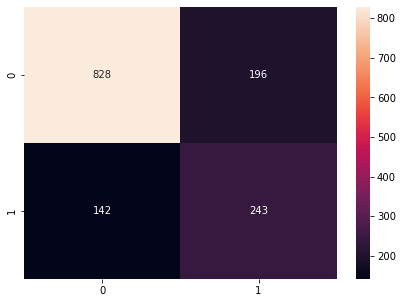

```
------ Save the pickle file ------

Pickle File saved


***********Testing pickle file***********

input:  [[1.00000000e+00 1.00000000e+00 0.00000000e+00 1.00000000e+00
  0.00000000e+00 1.00000000e+00 7.70149254e-01 5.36048927e-01
  0.00000000e+00 1.00000000e+00 0.00000000e+00 0.00000000e+00
  1.00000000e+00 0.00000000e+00 0.00000000e+00]
 [0.00000000e+00 1.00000000e+00 0.00000000e+00 0.00000000e+00
  0.00000000e+00 1.00000000e+00 3.15920398e-01 1.68024463e-01
  1.00000000e+00 0.00000000e+00 0.00000000e+00 0.00000000e+00
  0.00000000e+00 0.00000000e+00 1.00000000e+00]
 [0.00000000e+00 0.00000000e+00 0.00000000e+00 1.00000000e+00
  0.00000000e+00 0.00000000e+00 5.95024876e-01 6.83706439e-03
  1.00000000e+00 0.00000000e+00 0.00000000e+00 0.00000000e+00
  0.00000000e+00 1.00000000e+00 0.00000000e+00]
 [1.00000000e+00 0.00000000e+00 0.00000000e+00 0.00000000e+00
  0.00000000e+00 0.00000000e+00 4.30845771e-01 1.80377337e-01
  0.00000000e+00 1.00000000e+00 0.00000000e+00 0.00000000e+00
  0.00000000e+00 1.00000000e+00 0.00000000e+00]
 [1.00000000e+00 1.00000000e+00 1.00000000e+00 1.00000000e+00
  0.00000000e+00 1.00000000e+00 5.42786070e-01 1.05152319e-01
  1.00000000e+00 0.00000000e+00 0.00000000e+00 0.00000000e+00
  0.00000000e+00 1.00000000e+00 0.00000000e+00]
 [5.00000000e-01 5.00000000e-01 5.00000000e-01 5.00000000e-01
  5.00000000e-01 1.00000000e+00 1.19402985e-02 7.50057697e-05
  1.00000000e+00 0.00000000e+00 0.00000000e+00 0.00000000e+00
  0.00000000e+00 0.00000000e+00 1.00000000e+00]
 [1.00000000e+00 0.00000000e+00 1.00000000e+00 1.00000000e+00
  0.00000000e+00 0.00000000e+00 4.65174129e-01 3.85991230e-01
  1.00000000e+00 0.00000000e+00 0.00000000e+00 0.00000000e+00
  1.00000000e+00 0.00000000e+00 0.00000000e+00]
 [1.00000000e+00 1.00000000e+00 0.00000000e+00 1.00000000e+00
  0.00000000e+00 1.00000000e+00 7.50248756e-01 5.19426494e-01
  0.00000000e+00 1.00000000e+00 0.00000000e+00 0.00000000e+00
  0.00000000e+00 1.00000000e+00 0.00000000e+00]
 [5.00000000e-01 5.00000000e-01 5.00000000e-01 5.00000000e-01
  5.00000000e-01 0.00000000e+00 5.97014925e-03 5.76967459e-06
  1.00000000e+00 0.00000000e+00 0.00000000e+00 0.00000000e+00
  0.00000000e+00 1.00000000e+00 0.00000000e+00]]
Prediction Result : [0 0 1 0 0 1 0 0 0]
```

```python
def main():
    global df
    print("\n***********DATA LOADING***********\n")
    df=load_dataset("TelcomCustomer-Churn_2.csv")

    print("\n\n***********DATA CLEANING***********\n")
    unwantedfeature='customerID'
    Dclean=Datacleaning(df,unwantedfeature)

    #eencoding ordinal and categorical columns
    ordinal=['OnlineBackup','DeviceProtection','TechSupport','StreamingTV','StreamingMovies','PaperlessBilling','Churn']
    oneHotCols=["Contract","PaymentMethod"]

    print("\n\n***********DATA Preprocessing***********\n")
    Dprocessing=Datapreprocessing()
    encodedDF=Dprocessing.categorical_encoding(ordinal,oneHotCols,df)

    #define the input variables and target
    testratio=0.20
    seed=47
    inputvar= encodedDF.drop("Churn", axis=1)
    target=encodedDF['Churn']
    #scaling the inputs
    scaledinput=Dprocessing.featurescaling(inputvar)

    #split train and test data after scaling
    X_train, X_test, Y_train, Y_test=Dprocessing.Train_test_split(scaledinput, target, testratio ,seed)
    print("Xtrain shape :",X_train.shape)
    print("Xtest shape :",X_test.shape)
    print("Ytrain shape :",Y_train.shape)
    print("Ytest shape :",Y_test.shape)

    #resampling train data for balancing the data for target
    X_trainres,Y_trainres=Dprocessing.balancingtarget(X_train,Y_train)

    print("\n\n***********Model Building***********\n")
    #get the defind models
    Basemodel=BaseModeltraning()
    bmodels = Basemodel.GetBasedModel()
    #get cross validation result of base models
    bmnames,bmcvresults = Basemodel.Modelvalidation(X_trainres, Y_trainres,bmodels,seed)
    #Formating the results
    basemodelscore=Basemodel.scoringtable(bmodels,bmcvresults)
    print(basemodelscore)

    print("\n\n***********Tuning the Model ***********\n")
    #define parameters and models for Algo tning
    Tunedmodel=ModelBoosting()
    ptmodels = Tunedmodel.GethyperModel()
    #get the CVresults
    ptnames,ptcvresults = Tunedmodel.hypermodelvalidation(X_trainres, Y_trainres,ptmodels)
    #Formating the results
    hypertuningscore=Tunedmodel.tunescoringtable(ptmodels,ptnames,ptcvresults)
    print(hypertuningscore)

    print("\n\n***********Models with Best Parameters tuned***********\n")
    #creating object for the class
    ensmblmodel=IdentifyFinalModel()
    FBmodel=BaseModeltraning()
    #defining the models with best parameters identified in tuning models
    bestmodels = ensmblmodel.GetBestModel(ptcvresults)
    #getting the ensmodel score for models wth best parameters
    bestnames,bestcvresults = FBmodel.Modelvalidation(X_trainres, Y_trainres,bestmodels,seed)
    #Formating the result
    bestparamtunedscore=FBmodel.scoringtable(bestmodels,bestcvresults)
    print(bestparamtunedscore)

    print("\n\n***********Top 3 best models***********\n")
    #top3 models of above
    top3bestmodel=pd.concat([basemodelscore,hypertuningscore]).sort_values(['Score'] , ascending=False).head(3)
    print(top3bestmodel)

    #defining estimators as top3 models for voting classifier
    estimators=[]
    for index,rows in top3bestmodel.iterrows():
        estimators.append((rows['Modelname'],rows['Model']))

    print("\n\n***********Ensembling technique***********\n")
    #Voting classifier model building
    FinalModel=ensmblmodel.ensemblingBestModels(estimators,X_trainres,Y_trainres,X_test,Y_test)


    print("\n\n***********Evaluating final model***********\n")
    BestFModel=ensmblmodel.Evaluationmetrics(FinalModel,X_trainres,Y_trainres,X_test,Y_test)



    #save the pickel file
    picklefile=ensmblmodel.packthemodel(BestFModel)
    print("Pickle File saved")


    print("\n\n***********Testing pickle file***********\n")
    Deployedmodel = pickle.loads(picklefile)
    print("input: ",X_train[:9])
    print("Prediction Result :", Deployedmodel.predict(X_train[:9]))



if __name__ == "__main__":
    main()
```